# Descriptive Analysis of Neighborhood Change

# Overview

For this portion of the project, we are calculating Changes in Median Home Value and Neighborhood Metrics, from 2000 to 2010.

# Packages Used

```r
library( dplyr )
library( knitr )
library( pander )
library( stargazer )
library( here )
library( scales )
library( ggplot2 )
library( ggthemes )
library( gridExtra )
set.seed( 1234 )
s.type <- "text"
```

# Data

For this project, we are using data from the [Longitudinal Tabulated Database (LTDB)](https://s4.ad.brown.edu/projects/diversity/Researcher/Bridging.htm)

## Load and Merge Data

The first step is to download data for the years 2000 and 2010 along with their metadata and combine them into one dataset.

## Filter for Urban Cities

For this project we were interested in only urban areas, we omitted rural areas by filtering only urban tracts. We also omitted non-numeric values.

```r
d <- filter( d, urban.x == "urban" )
d$id2 <- gsub( "[^0-9]", "", d$tractid )
```

# Calculating MHV Change & Growth

## Accounting for Inflation

We accounted for inflation of the ($) USD, by multiplying 2000 Median Home Values by 1.28855

**TIP:** You can google “inflation calculator” to find a conversion rate, by a start and final year and use $1 as the starting value. [Westegg](https://westegg.com/inflation/) is one of an example.

Alternatively, you can always estimate it if you know the average long-term inflation rate. Since 2000 the rate has averaged about 2.5% in the US, so you can use:

10 year inflation factor (1.025)^10 [1] 1.280085

Prior to 2000 the rates were higher and they fluctuated quite a bit through the 70’s and 80’s so if you are going back in time further it is better to use a calculator. The calculators should use the actual rates by year.

```r
# adjust 2000 home values for inflation
mhv.00 <- d$mhmval00 * 1.28855
mhv.10 <- d$mhmval12
```

## Variable Creation

We then used these new relative values to determine the 10 year change in Median Home Value.

```r
# Median Home Value change ($) from 2000 to 2010
mhv.change <- mhv.10 - mhv.00
# Fliter out home values less than 10k
mhv.00[ mhv.00 < 1000 ] <- NA
# Median Home Value change ($) from 2000 to 2010
mhv.growth <- 100 * ( mhv.change / mhv.00 )
mhv.growth[ mhv.growth > 200 ] <- NA
# Adding Variables back into Dataset
d$mhv.00 <- mhv.00
d$mhv.10 <- mhv.10
d$mhv.change <- mhv.change
d$mhv.growth <- mhv.growth
```

# Calculating Neighborhood Change

## Formatting Neighborhood data

First, we will organize the neighborhood characteristic data, and create new variables.

```r
#Calculating new proportion variables from existing variables.
d <-
  d %>%
  mutate(
          # 2000 variables
          p.white.00 = 100 * nhwht00 / pop00.x,
          p.black.00 = 100 * nhblk00 / pop00.x,
          p.hisp.00 = 100 * hisp00 / pop00.x,
          p.asian.00 = 100 * asian00 / pop00.x,
          p.hs.edu.00 = 100 * (hs00+col00) / ag25up00,
          p.col.edu.00 = 100 * col00 / ag25up00,
          p.prof.00 = 100 * prof00 / empclf00,
          p.unemp.00 = 100 * unemp00 / clf00,
          pov.rate.00 = 100 * npov00 / dpov00,
          p.rent.00 = 100 * rent00 / hu00,
          # 2010 variables
          p.white.10 = 100 * nhwht10 / pop10,
          p.black.10 = 100 * nhblk10 / pop10,
          p.hisp.10 = 100 * hisp10 / pop10,
          p.asian.10 = 100 * asian10 / pop10,
          p.hs.edu.10 = 100 * (hs12+col12) / ag25up12,
          p.col.edu.10 = 100 * col12 / ag25up12,
          p.prof.10 = 100 * prof12 / empclf12,
          p.unemp.10 = 100 * unemp12 / clf12,
          pov.rate.10 = 100 * npov12 / dpov12,
          p.rent.10 = 100 * rent10 / hu10 )
```

Next, we will create variables to determine changes in our neighborhood characteristics of interest, similar to how we did with Change in Median Home Value

```r
# Calculate new variables using "group_by"
d <-
  d %>%
  group_by( cbsaname.x ) %>%
  mutate( metro.mhv.pct.00 = ntile( mhv.00, 100 ),
          metro.mhv.pct.10 = ntile( mhv.10, 100 ),
          metro.median.pay.00 = median( hinc00, na.rm=T ),
          metro.median.pay.10 = median( hinc12, na.rm=T ),
          metro.diversity.rank.00 = ntile( (100-p.white.00), 100 ),
          # metro total population 2000
          metro.pop.total.00 = sum( pop00.x, na.rm=T ),
          # metro total population 2010
          metro.pop.total.10 = sum( pop10, na.rm=T ),
          # tract rank in metro area for unemployment in 2000
          metro.unemp.rank.00 = ntile( p.unemp.00, 100 ),
          # tract rank in metro area for unemployment in 2010
          metro.unemp.rank.10 = ntile( p.unemp.10, 100 ) ) %>%
  ungroup() %>%
  mutate( metro.mhv.pct.change = metro.mhv.pct.10 - metro.mhv.pct.00,
          # metro population growth 2000-2010
          metro.pop.growth =
            ( metro.pop.total.10 - metro.pop.total.00 ) / metro.pop.total.00,
          metro.unemp.pct.change = metro.unemp.rank.10 - metro.unemp.rank.00,
          pay.change = metro.median.pay.10 - metro.median.pay.00,
          race.change = p.white.10 - p.white.00,
          pov.change = pov.rate.10 - pov.rate.00,
          p.unemp.change = p.unemp.10 - p.unemp.00,
          p.col.edu.change = p.col.edu.10 - p.col.edu.00,
          p.rent.change = p.rent.10 - p.rent.00)
# Keep only variables we need
d <-
  d %>%
  select( c( "tractid", "cbsa.x", "cbsaname.x",
          "mhv.00", "mhv.10", "mhv.change",
          "p.white.00", "p.black.00", "p.hisp.00", "p.asian.00",
          "p.col.edu.00", "p.col.edu.10", "pov.rate.00","pov.rate.10","p.unemp.00", "p.unemp.10", "p.rent.00", "p.rent.10", "metro.median.pay.00", "metro.median.pay.10",
          "metro.mhv.pct.00", "metro.median.pay.00", "metro.pop.total.00",
          "metro.unemp.pct.change", "metro.unemp.rank.00",
          "metro.pop.growth", "metro.mhv.pct.change", "pay.change", "race.change",
          "metro.diversity.rank.00", "pov.change", "p.unemp.change",
          "p.col.edu.change", "p.rent.change"
          ) )
# Create Dataset Backup
d.full <- d
d <- d.full
```

# Change in Median Home Value

If a home worth $10 million increased in value by $100k over ten years it would not be that surprising. If a home worth $50k increased by $100k over the same period that is a growth of 200% and is notable.

The change in value variable only reports absolute change, but does not provide a sense of whether that is a big or small amount for the census tract.

## Descriptive Statistics

```r
df <- data.frame( MedianHomeValue2000=mhv.00,
                  MedianHomeValue2010=mhv.10,
                  MHV.Change.00.to.10=mhv.change,
                  MHV.Growth.00.to.12=mhv.growth )

stargazer( df,
           type=s.type,
           digits=0,
           summary.stat = c("min", "p25","median","mean","p75","max") )
```

```
##
## ==========================================================================
## Statistic              Min     Pctl(25) Median   Mean   Pctl(75)    Max
## --------------------------------------------------------------------------
## MedianHomeValue2000   1,280    105,661  154,884 187,119 224,337  1,288,551
## MedianHomeValue2010   9,999    123,200  193,200 246,570 312,000  1,000,001
## MHV.Change.00.to.10 -1,228,651  7,187   36,268  60,047   94,881  1,000,001
## MHV.Growth.00.to.12    -97        6       25      29       49       200
## --------------------------------------------------------------------------
```

## Median Home Value ($)

The average change in Median Home Value was $ 60,047, while the Median was $36,268.

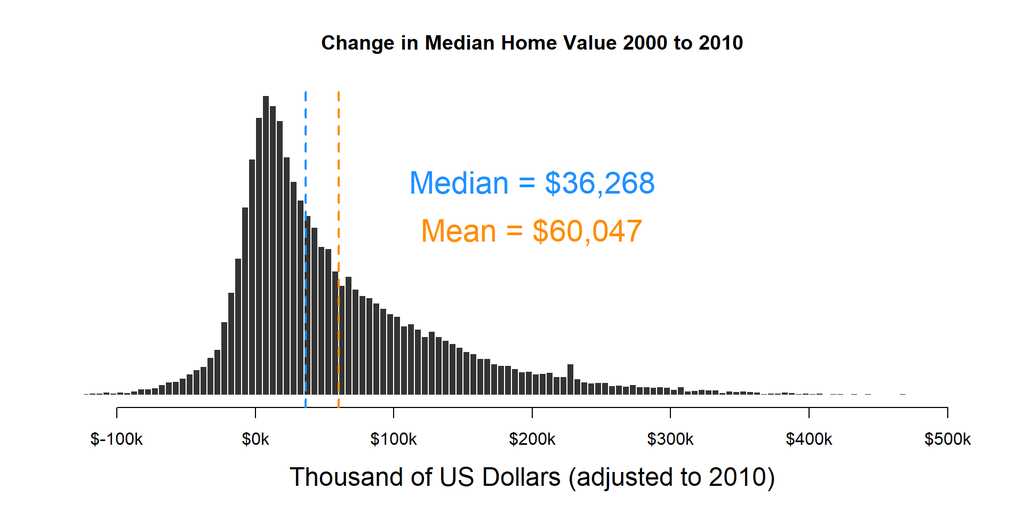

```r
hist( mhv.change/1000, breaks=500,
      xlim=c(-100,500), yaxt="n", xaxt="n",
      xlab="Thousand of US Dollars (adjusted to 2010)", cex.lab=1.5,
      ylab="", main="Change in Median Home Value 2000 to 2010",
      col="gray20", border="white" )

axis( side=1, at=seq( from=-100, to=500, by=100 ),
      labels=paste0( "$", seq( from=-100, to=500, by=100 ), "k" ) )

mean.x <- mean( mhv.change/1000, na.rm=T )
abline( v=mean.x, col="darkorange", lwd=2, lty=2 )
text( x=200, y=1500,
      labels=paste0( "Mean = ", dollar( round(1000*mean.x,0)) ),
      col="darkorange", cex=1.8, pos=3 )

median.x <- median( mhv.change/1000, na.rm=T )
abline( v=median.x, col="dodgerblue", lwd=2, lty=2 )
text( x=200, y=2000,
      labels=paste0( "Median = ", dollar( round(1000*median.x,0)) ),
      col="dodgerblue", cex=1.8, pos=3 )
```

## Median Home Value (%)

The average % change in Median Home Value was 29%, while the Median was 25%.

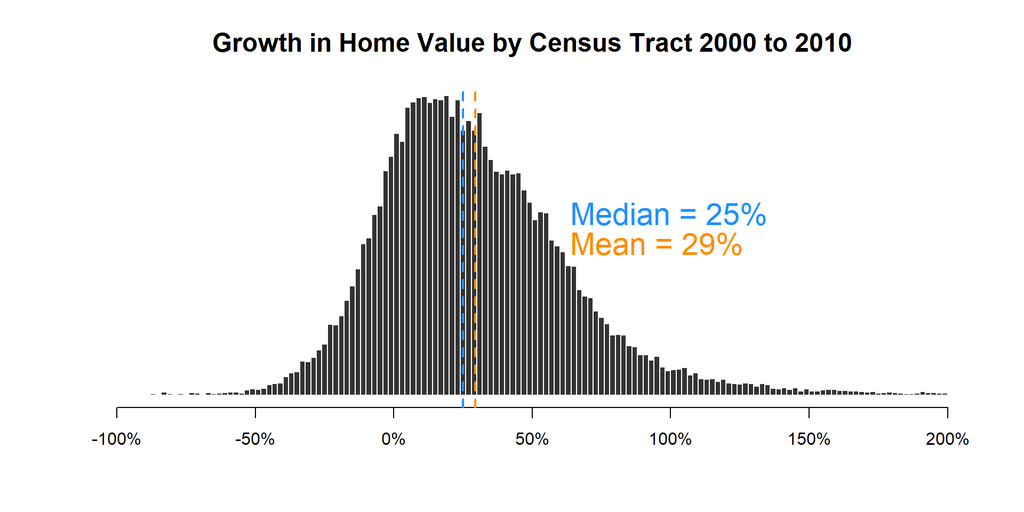

```r
hg <-
hist( mhv.growth, breaks=110,
      xlim=c(-100,200), yaxt="n", xaxt="n",
      xlab="", cex.main=1.5,
      ylab="", main="Growth in Home Value by Census Tract 2000 to 2010",
      col="gray20", border="white" )

axis( side=1, at=seq( from=-100, to=200, by=50 ),
      labels=paste0( seq( from=-100, to=200, by=50 ), "%" ) )

ymax <- max( hg$count )

mean.x <- mean( mhv.growth, na.rm=T )
abline( v=mean.x, col="darkorange", lwd=2, lty=2 )
text( x=60, y=(0.5*ymax),
      labels=paste0( "Mean = ", round(mean.x,0), "%"),
      col="darkorange", cex=1.8, pos=4 )

median.x <- median( mhv.growth, na.rm=T )
abline( v=median.x, col="dodgerblue", lwd=2, lty=2 )
text( x=60, y=(0.6*ymax),
      labels=paste0( "Median = ", round(median.x,0), "%"),
      col="dodgerblue", cex=1.8, pos=4 )
```

# Change in Neighborhood Metrics

**For this project, Group 1 chose to evaluate the following qualities, based on their ability to predict for gentrification:**

The variables used to identify neighborhoods that could be a candidate for gentrification were:

- **Education Level:** We look for neighborhoods that show a decrease in uneducated people as a signal for gentrification.
- **Poverty Rate:** We look at neighborhoods that show a decrease in poverty in the ten year span as an indicator for gentrification.
- **Unemployed Rate:** We look for areas that show a decrease in unemployment showing possible gentrification.
- **Proportion Renters:** We look at tracts that have a decrease in renters, signifying that people are more likely moving into housing units instead, showing possible gentrification.
- **Median Income:** Finally, we look at city-wide values for cities that show an increase in income.

## Decriptive Statistics

```r
df <- data.frame( Pct.College.Educated.00=d$p.col.edu.00/100,
                  Pct.College.Educated.10=d$p.col.edu.10/100,
                  Poverty.Rate.00=d$pov.rate.00/100,
                  Poverty.Rate.00=d$pov.rate.10/100,
                  Pct.Unemployed.00=d$p.unemp.00/100,
                  Pct.Unemployed.10=d$p.unemp.10/100,
                  Pct.Renters.00=d$p.rent.00/100,
                  Pct.Renters.10=d$p.rent.10/100,
                  Median.Income.00=d$metro.median.pay.00,
                  Median.Income.10=d$metro.median.pay.10
                  )

stargazer( df,
           type=s.type,
           digits=2,
           summary.stat = c("min", "p25","median","mean","p75","max") )
```

```
##
## ===================================================================================
## Statistic                  Min    Pctl(25)   Median     Mean    Pctl(75)     Max
## -----------------------------------------------------------------------------------
## Pct.College.Educated.00   0.00      0.12      0.21      0.26      0.36      1.00
## Pct.College.Educated.10   0.00      0.15      0.25      0.30      0.41      1.00
## Poverty.Rate.00           0.00      0.04      0.09      0.12      0.17      1.00
## Poverty.Rate.00.1         0.00      0.06      0.12      0.16      0.22      1.00
## Pct.Unemployed.00         0.00      0.03      0.05      0.06      0.08      1.00
## Pct.Unemployed.10         0.00      0.06      0.09      0.10      0.13      1.00
## Pct.Renters.00            0.00      0.15      0.27      0.32      0.46      1.00
## Pct.Renters.10            0.00      0.16      0.29      0.33      0.47      1.00
## Median.Income.00        23,012.00 39,457.00 43,139.18 45,053.63 49,522.00 73,701.00
## Median.Income.10        30,337.00 47,736.00 54,728.00 55,904.72 60,119.00 96,033.00
## -----------------------------------------------------------------------------------
```

## Education Level

The average % change in College Education Residents was 4%, while the Median was 3%.

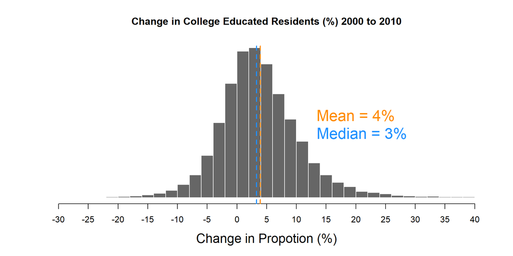

```r
hist( d$p.col.edu.change, breaks=100,
      xlim=c(-30,40), yaxt="n", xaxt="n",
      xlab="Change in Propotion (%)", cex.lab=1.5,
      ylab="", main="Change in College Educated Residents (%) 2000 to 2010",
      col="gray40", border="white" )

axis( side=1, at=seq( from= -30, to=40, by=5 ),
      labels=paste0( seq( from= -30, to= 40, by=5 )) )

mean.x <- mean( d$p.col.edu.change, na.rm=T )
abline( v=mean.x, col="darkorange", lwd=2, lty=2 )
text( x=20, y=4000,
      labels=paste0( "Mean = ", round(mean.x,0), "%" ),
      col="darkorange", cex=1.8, pos=3 )

median.x <- median( d$p.col.edu.change, na.rm=T )
abline( v=median.x, col="dodgerblue", lwd=2, lty=2 )
text( x=21, y=3000,
      labels=paste0( "Median = ",  round(median.x,0), "%" ),
      col="dodgerblue", cex=1.8, pos=3 )
```

## Poverty Rate

The average % change in Poverty Rate was 3%, while the Median was 2%.

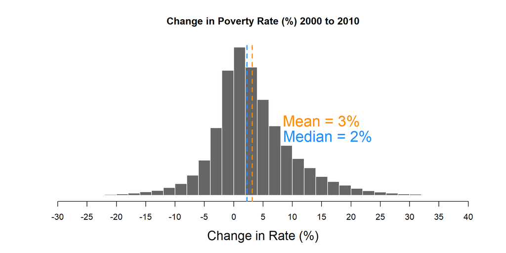

```r
hist( d$pov.change, breaks=100,
      xlim=c(-30,40), yaxt="n", xaxt="n",
      xlab="Change in Rate (%)", cex.lab=1.5,
      ylab="", main="Change in Poverty Rate (%) 2000 to 2010",
      col="gray40", border="white" )

axis( side=1, at=seq( from= -30, to=40, by=5 ),
      labels=paste0( seq( from= -30, to= 40, by=5 )) )

mean.x <- mean( d$pov.change, na.rm=T )
abline( v=mean.x, col="darkorange", lwd=2, lty=2 )
text( x=15, y=4200,
      labels=paste0( "Mean = ", round(mean.x,0), "%" ),
      col="darkorange", cex=1.8, pos=3 )

median.x <- median( d$pov.change, na.rm=T )
abline( v=median.x, col="dodgerblue", lwd=2, lty=2 )
text( x=16, y=3200,
      labels=paste0( "Median = ",  round(median.x,0), "%" ),
      col="dodgerblue", cex=1.8, pos=3 )
```

## Unemployment Rate

The average % change in Unemployment Rate was 4%. Median change was also 4%.

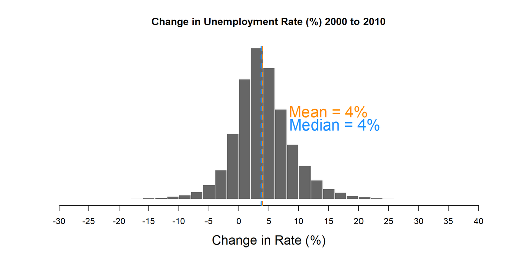

```r
hist( d$p.unemp.change, breaks=100,
      xlim=c(-30,40), yaxt="n", xaxt="n",
      xlab="Change in Rate (%)", cex.lab=1.5,
      ylab="", main="Change in Unemployment Rate (%) 2000 to 2010",
      col="gray40", border="white" )

axis( side=1, at=seq( from= -30, to=40, by=5 ),
      labels=paste0( seq( from= -30, to= 40, by=5 )) )

mean.x <- mean( d$p.unemp.change, na.rm=T )
abline( v=mean.x, col="darkorange", lwd=2, lty=2 )
text( x=15, y=6000,
      labels=paste0( "Mean = ", round(mean.x,0), "%" ),
      col="darkorange", cex=1.8, pos=3 )

median.x <- median( d$p.unemp.change, na.rm=T )
abline( v=median.x, col="dodgerblue", lwd=2, lty=2 )
text( x=16, y=5000,
      labels=paste0( "Median = ",  round(median.x,0), "%" ),
      col="dodgerblue", cex=1.8, pos=3 )
```

## Proportion Renters

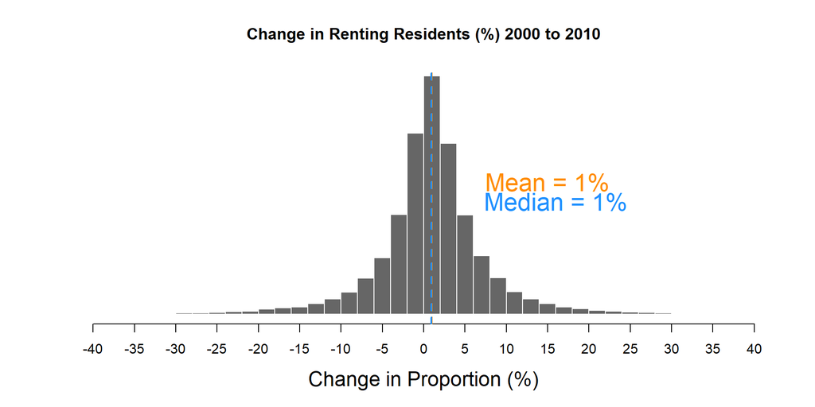

```r
hist( d$p.rent.change, breaks=100,
      xlim=c(-40,40), yaxt="n", xaxt="n",
      xlab="Change in Proportion (%)", cex.lab=1.5,
      ylab="", main="Change in Renting Residents (%) 2000 to 2010",
      col="gray40", border="white" )

axis( side=1, at=seq( from= -40, to=40, by=5 ),
      labels=paste0( seq( from= -40, to= 40, by=5 )) )

mean.x <- mean( d$p.rent.change, na.rm=T )
abline( v=mean.x, col="darkorange", lwd=2, lty=2 )
text( x=15, y=6000,
      labels=paste0( "Mean = ", round(mean.x,0), "%" ),
      col="darkorange", cex=1.8, pos=3 )

median.x <- median( d$p.rent.change, na.rm=T )
abline( v=median.x, col="dodgerblue", lwd=2, lty=2 )
text( x=16, y=5000,
      labels=paste0( "Median = ",  round(median.x,0), "%" ),
      col="dodgerblue", cex=1.8, pos=3 )
```

## Median Income

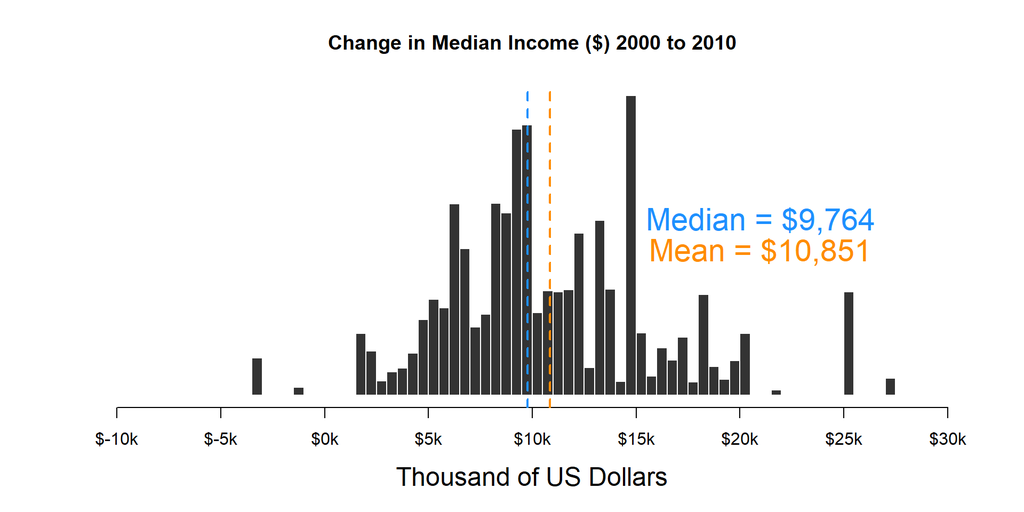

```r
hist( d$pay.change/1000, breaks=100,
      xlim=c(-10,30), yaxt="n", xaxt="n",
      xlab="Thousand of US Dollars", cex.lab=1.5,
      ylab="", main="Change in Median Income ($) 2000 to 2010",
      col="gray20", border="white" )

axis( side=1, at=seq( from=-10, to=30, by=5 ),
      labels=paste0( "$", seq( from=-10, to=30, by=5 ), "k" ) )

mean.x <- mean( d$pay.change/1000, na.rm=T )
abline( v=mean.x, col="darkorange", lwd=2, lty=2 )
text( x=21, y=2000,
      labels=paste0( "Mean = ", dollar( round(1000*mean.x,0)) ),
      col="darkorange", cex=1.8, pos=3 )

median.x <- median( d$pay.change/1000, na.rm=T )
abline( v=median.x, col="dodgerblue", lwd=2, lty=2 )
text( x=21, y=2500,
      labels=paste0( "Median = ", dollar( round(1000*median.x,0)) ),
      col="dodgerblue", cex=1.8, pos=3 )
```

# References

Baum-Snow, N., and Hartley, D. (2016). Accounting for central neighborhood change, 1980-2010. Federal Reserve Bank of Chicago (April 26, 2020). https://github.com/DS4PS/cpp-528-spr-2020/raw/master/articles/home-value-change/economic-model-central-city-neighborhoods-white-flight-white-return.pdf

Data Sciences for Public Service. (2020). Data Sciences III. Arizona State University MS in Program Evaluation & Data Analytics (April 26, 2020). https://ds4ps.org/cpp-528-spr-2020/labs/lab-06-tutorial.html

Way, H., Mueller, E., and Wegmann, J. (2018). Uprooted: Residential displacement in Austin’s gentrifying neighborhoods and what can be done about it. University of Texas (April 26, 2020). [Excerpt](https://r-class.github.io/cpp-528-spr-2020-group-01/files/gentrification-methodology.pdf) | [Full Report](https://www.urbandisplacement.org/sites/default/files/images/utgentrification-fullreport.pdf)

Analysis Created By: Group 1: Ricky Duran, Jason Eastman, & Katie Gantry For: CPP 528 - Data Sciences for Public Service III (Spring 2020) Created On: “April 30, 2020”